# reest

Maio de 2015

## Sumário

- Objetivos
- Motivação
- Alternativas
- R
- Exemplos
- Próximos Passos

## Objetivos

- **Coleta**
- Limpeza
- **Análise**
  - *Transformação/Manipulação*
  - *Visualização*
  - *Modelagem*
- Insight
- **Comunicação**

Fonte: [The Grammar and Graphics of Data Science](https://github.com/rstudio/webinars/blob/master/01-Grammar-and-Graphics-of-Data-Science/1-dplyr-tidyr.pdf)

## Motivação 1 - Vício em Planilhas

- O vício é o uso persistente de uma substância que causa prejuízo ao viciado e aos que com ele convivem.
- Não é a substância que causa o prejuízo - seu uso limitado pode ser beneficente. São as circunstâncias e a extensão do uso que determinam se o comportamento caracteriza vício ou não.
- Planilhas são uma invenção fenômenal - caso seu uso seja limitado as situações para as quais ela foi concebida.

Fonte: [Spreadsheet Addiction](http://www.burns-stat.com/documents/tutorials/spreadsheet-addiction/)

## Motivação 2 - Automatização

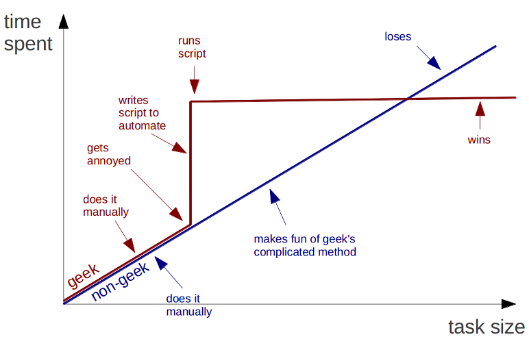

## Motivação 3 - Reprodutibilidade

- Replicabilidade (Replicável) *versus* Reprodutibilidade (Reprodutível) na pesquisa científica
- Replicabilidade - Mesmas descobertas científicas utilizando investigadores, métodos, dados, equipamentos e protocolos independentes
- Reprodutibilidade - Mesmas descobertas científicas utilizando investigadores independentes porém os mesmos métodos, dados, equipamentos e protocolos
- A replicabilidade algumas vezes pode ser impossivel de ser obtida, a reprodutibilidade é um padrão mínimo que podemos garantir

Fonte: [Reproducible research and Biostatistics](http://biostatistics.oxfordjournals.org/content/10/3/405.full)

## Motivação 4 - Computação e Software

- Software is eating the word!!!
- Regra de Dedo - Se você está tentando resolver um problema, e existem diversas empresas bilionárias cujo modelo de negócio inteiro depende de resolver o mesmo problema, e existem cursos inteiros na sua universidade dedicados a resolver esse problema, talvez seja uma boa idéia descobrir o que os especialistas fazem e ver se você não pode aprender uma coisa ou outra com eles.

Fonte: [Code and Data for the Social Sciences: A Practitioner´s Guide](http://faculty.chicagobooth.edu/matthew.gentzkow/research/CodeAndData.pdf)

## E agora José?

- Assumindo que a gente concorda com as motivações apresentadas, qual o caminho a partir daqui?
- Utilizar planilhas no mini-mundo para que elas foram concebidas, automatizar as tarefas que podem ser automatizadas, utilizar práticas e ferramentas que tornem nossas análises reproduziveis e aprender com a indústria do software como solucionar nossos problemas

## Alternativas

- **Vício em Planilhas**: R; QlikView; Access
- **Automatização** e **Reproducibility**: Scripting; Programação Literária
- **O Mundo do Software**: Controle de Versão; Teste Unitário; Programação em Pares; Padrões de Projeto

## Por que R?

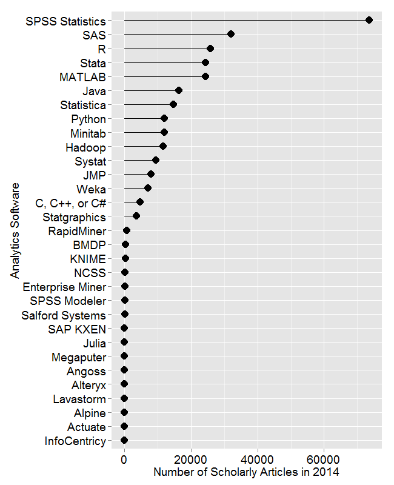

Fonte: [The Popularity of Data Analysis Software](http://r4stats.com/articles/popularity/)

## Por que R?

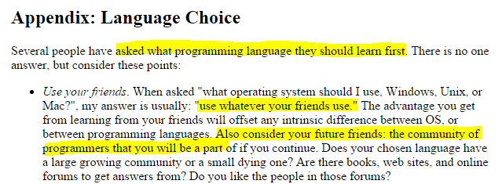

Fonte: [Teach Yourself Programming in Ten Years](http://norvig.com/21-days.html)

## Por que R?

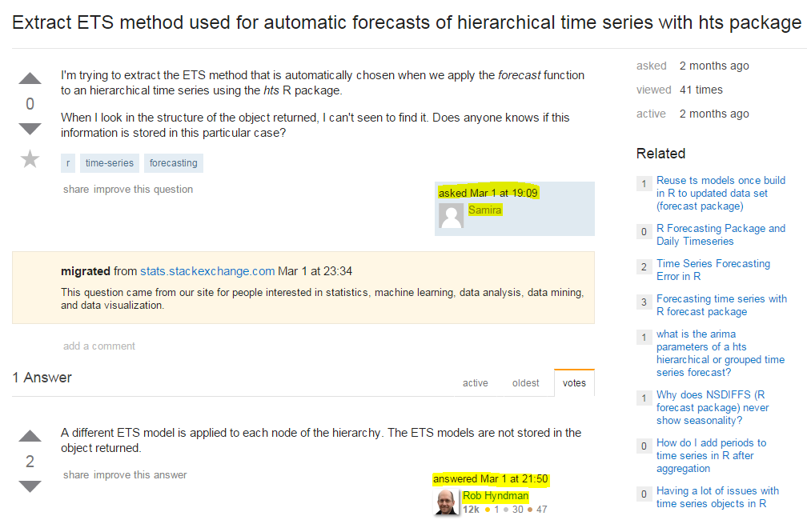

Fonte: [StackOverflow](http://stackoverflow.com/questions/28800583/extract-ets-method-used-for-automatic-forecasts-of-hierarchical-time-series-with)

## Seeing Is Believing

[figure not shown]

## Próximos Passos

- Abordagem ágil no gerenciamento de projetos de software
- Desenvolvimento de um pacote no R (`relatorios`) de forma incremental
- Estrutura base das funções

```r
relatorio(base_rec, base_desp,
       formato=c("base","relatorio","valor"),
       export=c("r","excel", "pdf"), ...) {
 ...
}
```